# Extended Data Fig. 15: Modeling direct and indirect effect rates

Andreas R. Gschwind

July 23, 2026

```r
library(tidyverse)
library(cowplot)
```

## Goal

Analyze direct vs. indirect effects across datasets and plot modeled direct effect rates as function of distance to TSS.

```r
# adjust path to indirect effects analysis output as needed to reproduce results
indirect_effects_dir <- "../../direct_vs_indirect_effects/compute_direct_vs_indirect_effects/results"

# output directory for generated plots
outdir <- "../extended_data_figure_15"
```

## Used data

Estimated cis and trans effect rates, as well as predicted direct rates and probability of direct vs indirect effects are used to plot direct and indirect rates.

```r
# load cis and trans effect rates
cis_rates <- read_tsv(file.path(indirect_effects_dir, "cis_positive_hit_rates.tsv"),
                      show_col_types = FALSE)
trans_rates <- read_tsv(file.path(indirect_effects_dir, "trans_positive_hit_rates.tsv"),
                        show_col_types = FALSE)

# load direct effect rates per dataset and averaged across datasets
direct_rates_datasets <- read_tsv(file.path(indirect_effects_dir, "direct_effect_models/direct_rates_per_datasets.tsv"),
                                  show_col_types = FALSE)
direct_rates_average  <- read_tsv(file.path(indirect_effects_dir, "direct_effect_models/direct_rates_average_across_datasets.tsv"),
                                  show_col_types = FALSE)

# load direct effect models
models <- readRDS(file.path(indirect_effects_dir, "direct_effect_models/direct_effects_model.rds"))

# load dataset ids
dataset_ids <- read_tsv(file.path(indirect_effects_dir, "../config/crispr_dataset_ids.tsv"),
                        show_col_types = FALSE)

# add dataset ids to use in plots to cis, trans and direct rates
dataset_ids_rates <- select(dataset_ids, dataset, dataset_plots)
cis_rates <- left_join(cis_rates, dataset_ids_rates, by = "dataset")
trans_rates <- left_join(trans_rates, dataset_ids_rates, by = "dataset")
direct_rates_datasets <- left_join(direct_rates_datasets, dataset_ids_rates, by = "dataset")
```

## Model direct effect rate

The cis positive hit rate is a combination of the direct and indirect hit rate. The expected indirect hit rate in these CRISPR experiments was estimated by the trans positive hit rate. We can now calculate the estimated direct effect hit rates by subtracting the indirect effects rate (trans hit rate) from the cis positive hit rate for each distance bin.

Some distance bins do have a lower (or 0) cis hit rate in some datasets due to the overall sparsity of positive hits in these experiments. Thus the resulting negative direct hit rate will can be considered an artifact.

To model the direct hit rate as a function of distance to TSS, we average the calculated direct effects hit rate across all dataset per distance bin and fit a powerlaw model. The following plots show the powerlaw fit visualized on the direct effect hit rates averaged across datasets.

```r
# plot direct effects model fit
plot_powerlaw_model_fit <- function(rate_type = c("all", "negative", "positive"),
                                    models, direct_rates_average, log = FALSE, ylim = NA) {

  rate_type <- match.arg(rate_type)

  # get direct rates for given rate type
  rate_type_data <- paste0("direct_rate_", rate_type)  # rate type in data and model list
  direct_rates_avg_type <- filter(direct_rates_average, type == rate_type_data)

  # get model coefficients for given rate type
  model_type <- models[[rate_type_data]]
  a <- exp(coef(model_type)[1])
  b <- coef(model_type)[2]

  # plot model fit vs average direct rate per dataset
  p <- ggplot(direct_rates_avg_type, aes(x = dist_to_tss, y = direct_rate)) +
    geom_point(color = "steelblue") +
    stat_function(fun = function(x) a * x^b, color = "black") +
    labs(title = str_to_sentence(paste("Direct hit rate", rate_type, "effects")),
         x = "Distance to TSS (bp)", y = "Direct hit rate") +
    scale_x_continuous(labels = scales::label_scientific(digits = 1)) +
    scale_y_continuous(limits = c(NA, ylim)) +
    theme_classic() +
    theme(text = element_text(size = 13))

  # transform plots to log space if specified
  if (log == TRUE) {
    p <- p +
      scale_x_log10() +
      scale_y_log10(limits = c(NA, ylim)) +
      annotation_logticks()
  }

  return(p)

}
```

Plot effect rates in log space. Note that this introduces infinite values in the direct hit rates because some distance bins have no positives due to overall data sparsity.

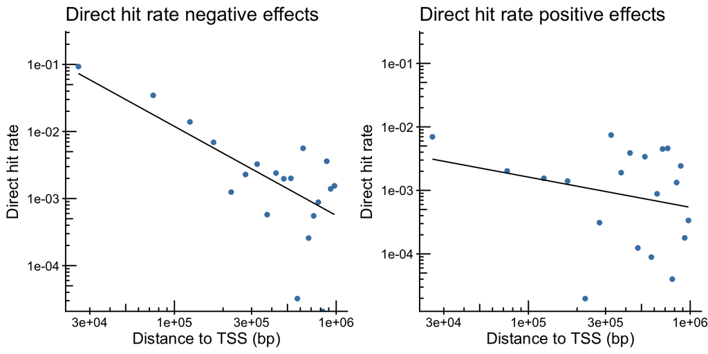

```r
# plot all model fits
rate_types <- c(negative = "negative", positive = "positive")
model_fit_plots <- lapply(rate_types, FUN = plot_powerlaw_model_fit, models = models,
                          direct_rates_average = direct_rates_average,
                          ylim = 0.2, log = TRUE)

# arrange all plots into on figure
p1 <- plot_grid(plotlist = model_fit_plots, nrow = 1)
p1
```

## Predicted direct effects rate

Using the powerlaw model, we can predict the direct effects rate as function of distance to TSS. The following plots show the predicted direct effect rates as function of distance to TSS for both negative and positive effects on expression. Empirically calculated indirect effect rates are overlayed as horizontal lines.

```r
# function to predict the direct hit rate for a given distance
predict_direct_hit_rate <- function(models, new_data, type) {

  # get model for specified type
  type <- paste0("direct_rate_", type)
  fit <- models[[type]]

  # predict direct hit rate for provided distances and exponentiate to get back to original scale
  predicted_log_direct_rate <- predict(fit, newdata = new_data)
  predicted_direct_rate <- exp(predicted_log_direct_rate)

  # cap predicted values at 1, because the rate can't be higher than that and add to input data
  new_data$predicted_direct_rate <- pmin(predicted_direct_rate, 1)

  return(new_data)

}
```

```r
# convert trans rates to long format and calculate average indirect rate across datasets
trans_rates <- trans_rates %>%
  select(dataset_plots, all = positive_rate_significant, negative = positive_rate_negative,
         positive = positive_rate_positive) %>%
  pivot_longer(cols = -dataset_plots, names_to = "effect_direction", values_to = "indirect_rate") %>%
  filter(effect_direction %in% rate_types)

# predict direct effects rate from 1bp to 1Mb distance to TSS and combine into one table
direct_effects_1mb <- lapply(rate_types, FUN = predict_direct_hit_rate, models = models,
                             new_data = tibble(dist_to_tss = 1:1e6)) %>%
  bind_rows(.id = "effect_direction")
```

### Average indirect rates across all datasets

Show average indirect rates across all datasets as horizontal lines.

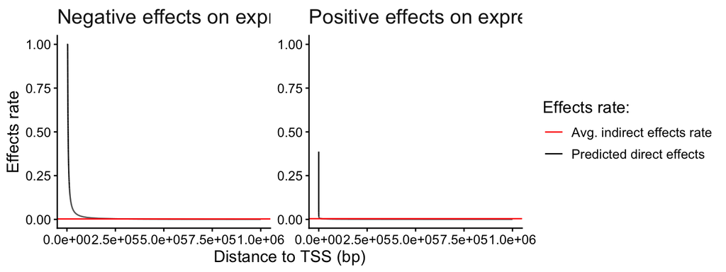

```r
# prettier effect directions for plots
direct_effects_1mb <- direct_effects_1mb %>%
  mutate(effect_direction = paste(str_to_title(effect_direction), "effects on expression"))
trans_rates <- trans_rates %>%
  mutate(effect_direction = paste(str_to_title(effect_direction), "effects on expression"))

# compute average indirect effect rates per effect size direction
avg_trans_rates <- trans_rates %>%
  group_by(effect_direction) %>%
  summarize(hit_rate = mean(indirect_rate))

# add rate labels for plots
direct_effects_1mb <- mutate(direct_effects_1mb, rate_label = "Predicted direct effects")
avg_trans_rates <- mutate(avg_trans_rates, rate_label = "Avg. indirect effects rate")

# plot predicted effects rate as function of distance to TSS plus average indirect rate
p2 <- ggplot(direct_effects_1mb,
             aes(x = dist_to_tss, y = predicted_direct_rate, color = rate_label)) +
  facet_wrap(~effect_direction, scales = "free_y") +
  geom_line() +
  geom_hline(data = avg_trans_rates, aes(yintercept = hit_rate, color = rate_label)) +
  labs(x = "Distance to TSS (bp)", y = "Effects rate", color = "Effects rate:") +
  scale_color_manual(values = c(`Avg. indirect effects rate` = "red",
                                `Predicted direct effects` = "black")) +
  scale_x_continuous(labels = scales::label_scientific()) +
  scale_y_continuous(limits = c(0, 1)) +
  theme_classic() +
  theme(strip.background = element_blank(), text = element_text(size = 13),
        strip.text = element_text(hjust = 0, size = 16, margin = margin(b = 8)))

p2
```

### Highlight K562 & WTC11 indirect rates

Show individual indirect rates for K562 and WTC11 datasets and average indirect rates across all other datasets as horizontal lines.

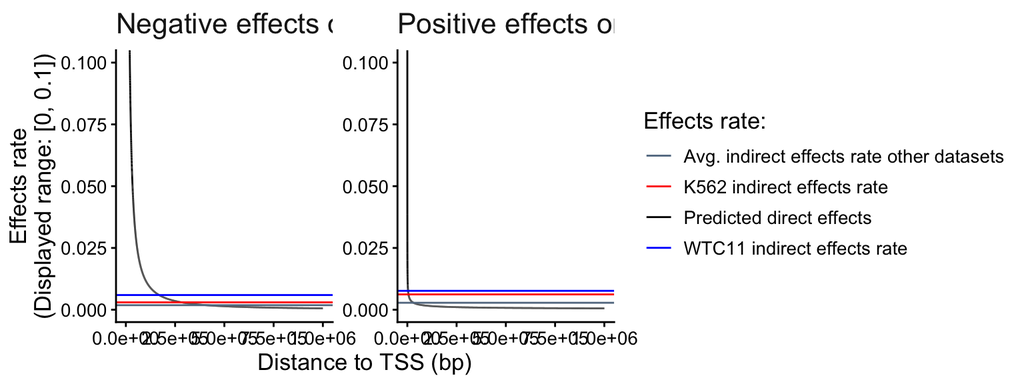

```r
# compute average indirect effect rates only for datasets other than DC-TAP-seq
trans_rates_plot <- trans_rates %>%
  mutate(rate_label = case_when(
    dataset_plots == "DC-TAP-seq (K562)" ~ "K562 indirect effects rate",
    dataset_plots == "DC-TAP-seq (WTC11)" ~ "WTC11 indirect effects rate",
    TRUE ~ "Avg. indirect effects rate other datasets"
  )) %>%
  group_by(rate_label, effect_direction) %>%
  summarize(hit_rate = mean(indirect_rate))

# colors for the different rates
rate_colors <- c(
  `Predicted direct effects` = "black",
  `K562 indirect effects rate` = "red",
  `WTC11 indirect effects rate` = "blue",
  `Avg. indirect effects rate other datasets` = "#637a91"

)

# plot rates and clip y-axis at 0.1 for better visualization
p3 <- ggplot(direct_effects_1mb,
             aes(x = dist_to_tss, y = predicted_direct_rate, color = rate_label)) +
  facet_wrap(~effect_direction, scales = "free_y") +
  geom_line() +
  geom_hline(data = trans_rates_plot, aes(yintercept = hit_rate, color = rate_label)) +
  labs(x = "Distance to TSS (bp)", y = "Effects rate\n(Displayed range: [0, 0.1])",
       color = "Effects rate:") +
  scale_color_manual(values = rate_colors) +
  scale_x_continuous(labels = scales::label_scientific()) +
  coord_cartesian(ylim = c(0, 0.1)) +
  theme_classic() +
  theme(strip.background = element_blank(), text = element_text(size = 13),
        strip.text = element_text(hjust = 0, size = 16, margin = margin(b = 8)))

p3
```

## Arrange supplementary figure

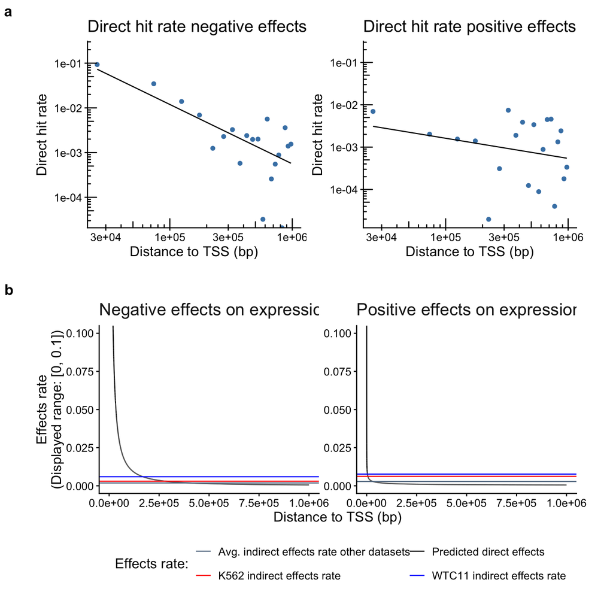

```r
# arrange panels into figure
plot_grid(
  p1,
  p3 + theme(legend.position = "bottom") + guides(color = guide_legend(nrow = 2)),
  labels = c("a", "b"),
  ncol = 1,
  scale = 0.9,
  rel_heights = c(1, 1.2)
  )
```

```r
# save figure to pdf
ggsave(file = file.path(outdir, "ExtData_Fig15_direct_indirect_rates.pdf"), height = 8, width = 8)
```